# 5. Model Training and Tuning

Russ Conte

2022-05-22

# Model Training and Tuning

Contents

5.1 Model Training and Parameter Tuning  
5.2 An Example  
5.3 Basic Parameter Tuning  
5.4 Notes on Reproducibility  
5.5 Customizing the Tuning Process  
5.5.1 Pre-Processing Options  
5.5.2 Alternate Tuning Grids  
5.5.3 Plotting the Resampling Profile  
5.5.4 The `trainControl` Function  
5.5.5 Alternate Performance Metrics  
5.6 Choosing the Final Model  
5.7 Extracting Predictions and Class Probabilities  
5.8 Exploring and Comparing Resampling Distrubutions  
5.8.1 Within-Model  
5.8.2 Between-Models  
5.9 Fitting Models Without Parameter Tuning

### 5.1 Model Training and Paramter Tuning

The `caret` package has several functions that attempt to streamline the model building and evaluaton process.

The `train` function can be used to: * Evaluate, using resampling, the effect of model tuning parameters on model performance * Choose the “optimal” model across these parameters * Estimate model performance from a training set

First, a specific model must be chosen. Current, 238 are available using `caret`.

The first step in tuning the model (line 1 in the algorithm below) is to choose a set of parameters to evaluate. For example, if fitting a Partial Least Squares (PLS) model, the number of PLS components to evaluate must be specified:

1. Define sets of model parameter values to evaluate
2. **for** *each parameter set* **do**
3. **for** *each resampling iteration* **do**  
   4. Hold-out Specific Items  
   5. [Optional] Pre-Process the data  
   6. Fit the model on the remainder  
   7. Predict the Hold-out samples
4. **end**
5. Calculate the average performanc across hold-out predictions
6. **end**
7. Determine the optimal parameter set
8. Fit the final model to all the training data using the optimal parameter set.

Once the model and tuning parameter values have been defined, the type of resampling should also be specified. Currently, *k*-fold cross-validation(once or repeated), leave-one-out cross-validation and bootstrap (simple estimation or the 632 rule) resampling methods can be used by `train`. After resampling, the process produces a profile of performance measure available to guide the user as to which tuning parameter values should be chosen. By default, the function augomatically chooses the tuning parameters associationed with the best values, although different algorithms can be used (see details below)

### 5.2. An Example

The Sonar data are available in the `mlbench` package. Here, we load the data:

```r
library(mlbench)
data(Sonar)
str(Sonar[,1:10])
```

```
## 'data.frame':    208 obs. of  10 variables:
##  $ V1 : num  0.02 0.0453 0.0262 0.01 0.0762 0.0286 0.0317 0.0519 0.0223 0.0164 ...
##  $ V2 : num  0.0371 0.0523 0.0582 0.0171 0.0666 0.0453 0.0956 0.0548 0.0375 0.0173 ...
##  $ V3 : num  0.0428 0.0843 0.1099 0.0623 0.0481 ...
##  $ V4 : num  0.0207 0.0689 0.1083 0.0205 0.0394 ...
##  $ V5 : num  0.0954 0.1183 0.0974 0.0205 0.059 ...
##  $ V6 : num  0.0986 0.2583 0.228 0.0368 0.0649 ...
##  $ V7 : num  0.154 0.216 0.243 0.11 0.121 ...
##  $ V8 : num  0.16 0.348 0.377 0.128 0.247 ...
##  $ V9 : num  0.3109 0.3337 0.5598 0.0598 0.3564 ...
##  $ V10: num  0.211 0.287 0.619 0.126 0.446 ...
```

The function `createDataPartition` can be used to create a stratified random sample of data into training and test sets:

```r
library(caret)
set.seed(998)
inTraining <- createDataPartition(Sonar$Class, p = 0.75, list = FALSE)
training <- Sonar[inTraining,]
testing <- Sonar[-inTraining,]

training[1:10, 1:10] # 157 observations of 61 variables
```

```
##        V1     V2     V3     V4     V5     V6     V7     V8     V9    V10
## 1  0.0200 0.0371 0.0428 0.0207 0.0954 0.0986 0.1539 0.1601 0.3109 0.2111
## 2  0.0453 0.0523 0.0843 0.0689 0.1183 0.2583 0.2156 0.3481 0.3337 0.2872
## 3  0.0262 0.0582 0.1099 0.1083 0.0974 0.2280 0.2431 0.3771 0.5598 0.6194
## 5  0.0762 0.0666 0.0481 0.0394 0.0590 0.0649 0.1209 0.2467 0.3564 0.4459
## 6  0.0286 0.0453 0.0277 0.0174 0.0384 0.0990 0.1201 0.1833 0.2105 0.3039
## 7  0.0317 0.0956 0.1321 0.1408 0.1674 0.1710 0.0731 0.1401 0.2083 0.3513
## 9  0.0223 0.0375 0.0484 0.0475 0.0647 0.0591 0.0753 0.0098 0.0684 0.1487
## 10 0.0164 0.0173 0.0347 0.0070 0.0187 0.0671 0.1056 0.0697 0.0962 0.0251
## 12 0.0123 0.0309 0.0169 0.0313 0.0358 0.0102 0.0182 0.0579 0.1122 0.0835
## 13 0.0079 0.0086 0.0055 0.0250 0.0344 0.0546 0.0528 0.0958 0.1009 0.1240
```

```r
testing[1:10, 1:10] # 51 observations of 61 variables
```

```
##        V1     V2     V3     V4     V5     V6     V7     V8     V9    V10
## 4  0.0100 0.0171 0.0623 0.0205 0.0205 0.0368 0.1098 0.1276 0.0598 0.1264
## 8  0.0519 0.0548 0.0842 0.0319 0.1158 0.0922 0.1027 0.0613 0.1465 0.2838
## 11 0.0039 0.0063 0.0152 0.0336 0.0310 0.0284 0.0396 0.0272 0.0323 0.0452
## 14 0.0090 0.0062 0.0253 0.0489 0.1197 0.1589 0.1392 0.0987 0.0955 0.1895
## 15 0.0124 0.0433 0.0604 0.0449 0.0597 0.0355 0.0531 0.0343 0.1052 0.2120
## 17 0.0352 0.0116 0.0191 0.0469 0.0737 0.1185 0.1683 0.1541 0.1466 0.2912
## 19 0.0270 0.0092 0.0145 0.0278 0.0412 0.0757 0.1026 0.1138 0.0794 0.1520
## 22 0.0664 0.0575 0.0842 0.0372 0.0458 0.0771 0.0771 0.1130 0.2353 0.1838
## 28 0.0177 0.0300 0.0288 0.0394 0.0630 0.0526 0.0688 0.0633 0.0624 0.0613
## 32 0.0084 0.0153 0.0291 0.0432 0.0951 0.0752 0.0414 0.0259 0.0692 0.1753
```

### 5.3 Basic Parameter Tuning

By default, simple bootstrap resampling is used for line 3 in the algorithm above. Other methods are available, such as *K*-fold cross-validation, leave-one-out, etc. The function, `trainControl` can be used to specify the type of resampling:

```r
fitControl <- trainControl(## 10-fold cross-validation,
                            method = "repeatedcv",
                            number = 10,
                            ## repeated ten times,
                            repeats = 10)
```

More information about `trainControl` is given in a section below.

The first two arguments to `train` are the predictor and outcome data objects, respectively. The third argument, `method`, specifies the type of model. To illustrate, we will fit a boosted tree model via the `gbm` package. The basic syntax for fitting this model using repeated cross-validation is shown below:

```r
set.seed(825)
gbmfit1 <- train(Class~., data = training,
                 method = "gbm",
                 trControl = fitControl,
                 ## This last option is actually one for gbm() that passes through
                 verbose = FALSE)
gbmfit1
```

```
## Stochastic Gradient Boosting
##
## 157 samples
##  60 predictor
##   2 classes: 'M', 'R'
##
## No pre-processing
## Resampling: Cross-Validated (10 fold, repeated 10 times)
## Summary of sample sizes: 141, 142, 141, 142, 141, 142, ...
## Resampling results across tuning parameters:
##
##   interaction.depth  n.trees  Accuracy   Kappa
##   1                   50      0.7935784  0.5797839
##   1                  100      0.8171078  0.6290208
##   1                  150      0.8219608  0.6383173
##   2                   50      0.8041912  0.6027771
##   2                  100      0.8296176  0.6544713
##   2                  150      0.8283627  0.6520181
##   3                   50      0.8110343  0.6170317
##   3                  100      0.8307941  0.6564891
##   3                  150      0.8317010  0.6590524
##
## Tuning parameter 'shrinkage' was held constant at a value of 0.1
##
## Tuning parameter 'n.minobsinnode' was held constant at a value of 10
## Accuracy was used to select the optimal model using the largest value.
## The final values used for the model were n.trees = 150, interaction.depth =
##  3, shrinkage = 0.1 and n.minobsinnode = 10.
```

- number of iterations, i.e. trees, (called `n.trees` in the `gbm` function)
- complexity of the tree, called `interaction.depth`
- learning rate: how quickly the algorithm adapts, called `shrinkage`
- the minimum number of training set samples in a note to commence splitting(`n.minobsinnode`)

The default values tested for this model are shown in the first two columns (`shrinkage` and `n.minobsinnode` are not shown because the grid set of candidate models all use a single value for these tuning parameters). The column labeled `accuracy` is the overall agreement rate averaged over cross-validation iterations. The agreement standard deviation is also calculated from the cross-validation results. The column, `Kappa` is Cohen’s (unweighted) Kappa statistic averaged across the resampling results. `train` works with specific models. For these models, `train` can automatically create a grid of tuning parameters. By default, if *p* is the number of tuning parameters, the grid size is 3^p. As another example, regularized discriminant analysis (RDA) models have two parameters (`gamma` and `lambda`), both of which lie between zero and one. The default trainng grid would produce nine combinations in this two-dimensional space.

### 5.4 Notes on Reproducibility

Many models utilize random numbers during the phase where parameters are estimated. Also, the resampling indices are chosen using random numbers. There are two main ways to control the randomness in order to assure reproducible results:

- There are two approaches to ensuring that the same *resamples* are used between calls to `train`. The first is to use `set.seed` just prior to calling `train`. The first use of random numbers is to create the resampling information. Alternatively, if you would like to use specific splits of the data, the `index` argument of the `trainControl` function can be used. This is briefly discussed below.
- When the models are created *inside of resampling*, the seeds can also be set. While setting the seed prior to calling `train` may guarantee that the same rendom numbers are used, this is unlikely to be the case when parallel processing is used (depending on which technology is utilized). To set the model fitting seeds, `trainControl` has an additional argument called `seeds` that can be used. The value for this argument is a list of integer vectors that are used as seeds. The help oage for `trainControl` describes the appropriate format for this option.

### 5.5 Customizing the Tuning Process

There are a few ways to customize the process of selecting tuning/complexity parameters and building the final model.

#### 5.5.1 Pre-Processing Options

As previously mentioned, `train` can pre-process the data in various ways prior to model fitting. The function `preProcess` is automatically used. The function can be used for centering and scaling imputation (see details below) applying the spatial sign transformation and feature extraction via principal component analysis or independent component analysis.

To specify what pre-processing should occur, the `train` function has an argument called `preProcess`. This argument takes a character string of methods that would normally be passed to the `method` argument of the `preProcess` function. Additional options to the `preProcess` function can be passed via the `trainControl` function.

These processing steps would be applied during any predictions generated using `predict.train`, `extractPrediction` or `extractProbs` (see details later in this document). The pre-processing would **not** be applied to predictions that directly use the `object$finalModel` object.

For imputation, there are three methods currently implemented:

- *k*-nearest neighbors takes a sample with missing values and finds the *k* closest samples in the training set. The average of the *k* training set values for that predictor are used as a substitute for the original data. When calculating the distrances to the training set samples, the predictors used in the calculation are the ones with no missing values for that sample and no missing values in the training set.
- Another approach is to fit a bagged tree model for each predictor using the training set samples. This is usually a fairly accurate model and can handle missing values. When a predictor for a sample requires imputation, the values for the other predcitors are fed through the bagged tree and the prediction is used as the new value. The model van have significant computational cost.
- The median of the predictor’s training set, PCA and ICA models only use complete samples.

#### 5.5.2 Alternate Tuning Grids

The tuning parameter grid can be specified by the user. The argument `tuneGrid` can take a data frame with columns for each tuning parameter. The column names should be the same as the fitting function’s arguments. For the previously mentioned RDA a example, the names would be `gamma` and `lambda`. `train` will tune the model over each combination of values in the rows

For the boosted tree model, we can fix the learning rate and evaluate more than three values of `n.trees`:

```r
gbmGrid <- expand.grid(interaction.depth = c(1,5,9),
                       n.trees = (1:30) * 50,
                       shrinkage = 0.1,
                       n.minobsinnode = 20)

nrow(gbmGrid)
```

```
## [1] 90
```

```r
set.seed(825)

gbmFit2 <- train(Class ~ ., data = training,
                 method = "gbm",
                 trControl = fitControl,
                 verbose = FALSE,
                 ## Now specify the exact models to evaluate:
                 tuneGrid = gbmGrid)

gbmFit2
```

```
## Stochastic Gradient Boosting
##
## 157 samples
##  60 predictor
##   2 classes: 'M', 'R'
##
## No pre-processing
## Resampling: Cross-Validated (10 fold, repeated 10 times)
## Summary of sample sizes: 141, 142, 141, 142, 141, 142, ...
## Resampling results across tuning parameters:
##
##   interaction.depth  n.trees  Accuracy   Kappa
##   1                    50     0.7828554  0.5576364
##   1                   100     0.8050417  0.6052511
##   1                   150     0.8197598  0.6347029
```

[output cut: 94 more lines]

#### 5.5.3 Plotting the Resampling Profile

The `plot` function can be used to examine the relationship between estimates of performance and the tuning parameters. For example, a simple invocation of the function shows the results for the first performance measure::

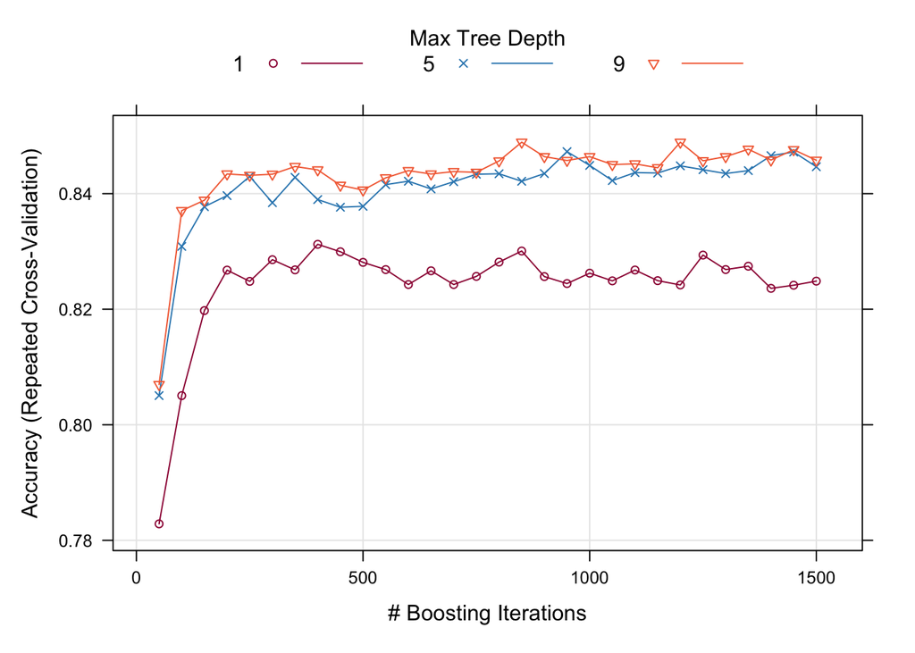

```r
trellis.par.set(caretTheme())
plot(gbmFit2)
```

Other performance metrics can be shown using the `metric` option:

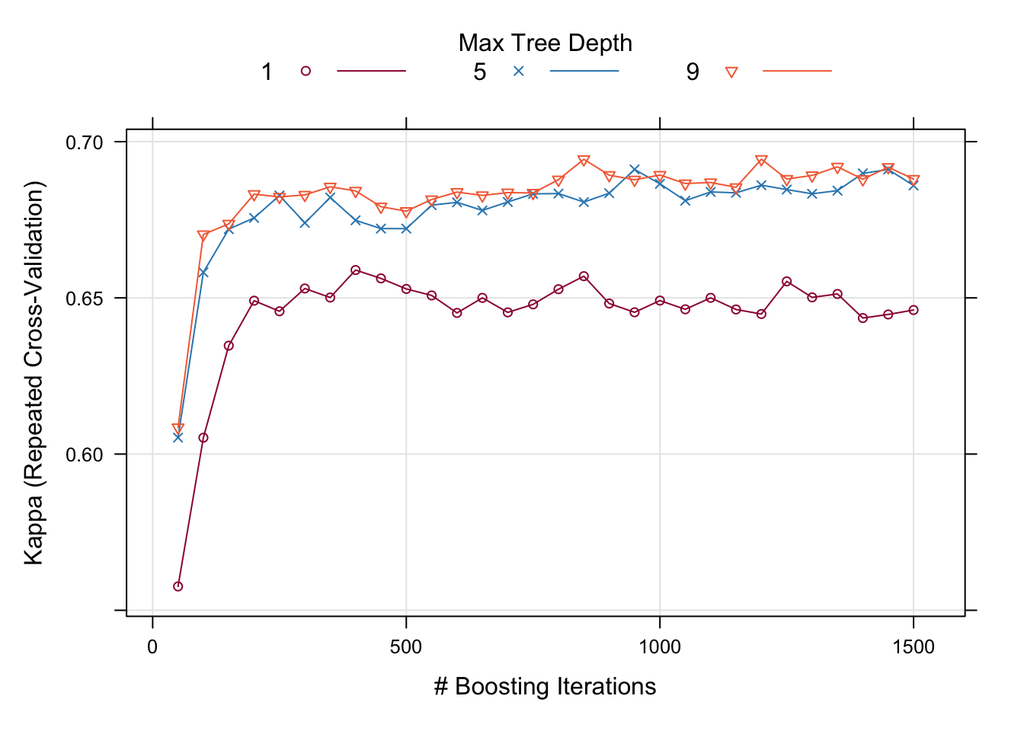

```r
trellis.par.set(caretTheme())
plot(gbmFit2, metric = "Kappa")
```

Other types of plots are also available. See `?plot.train` for more details. The code below shows a heatmap of the results:

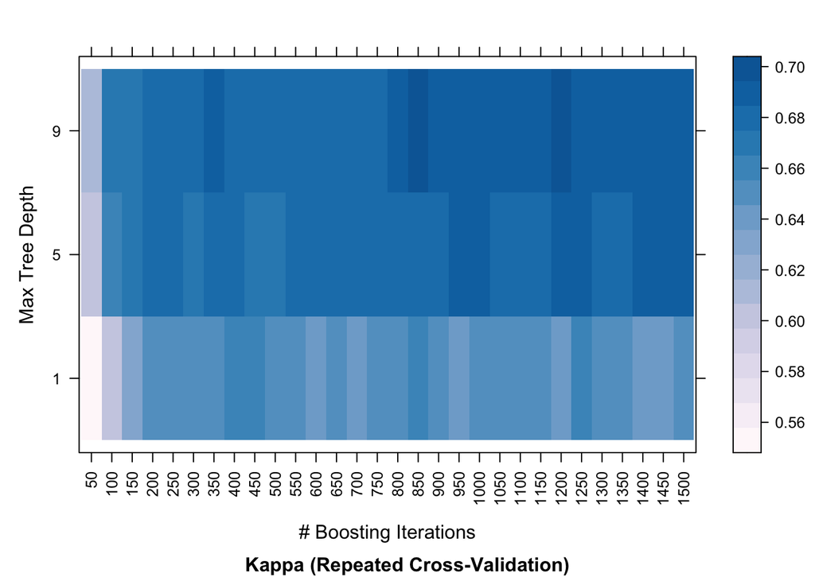

```r
trellis.par.set(caretTheme())
plot(gbmFit2, metric = "Kappa", plotType = "level", scales = list(x = list(rot = 90)))
```

A `ggplot` method can also be used:

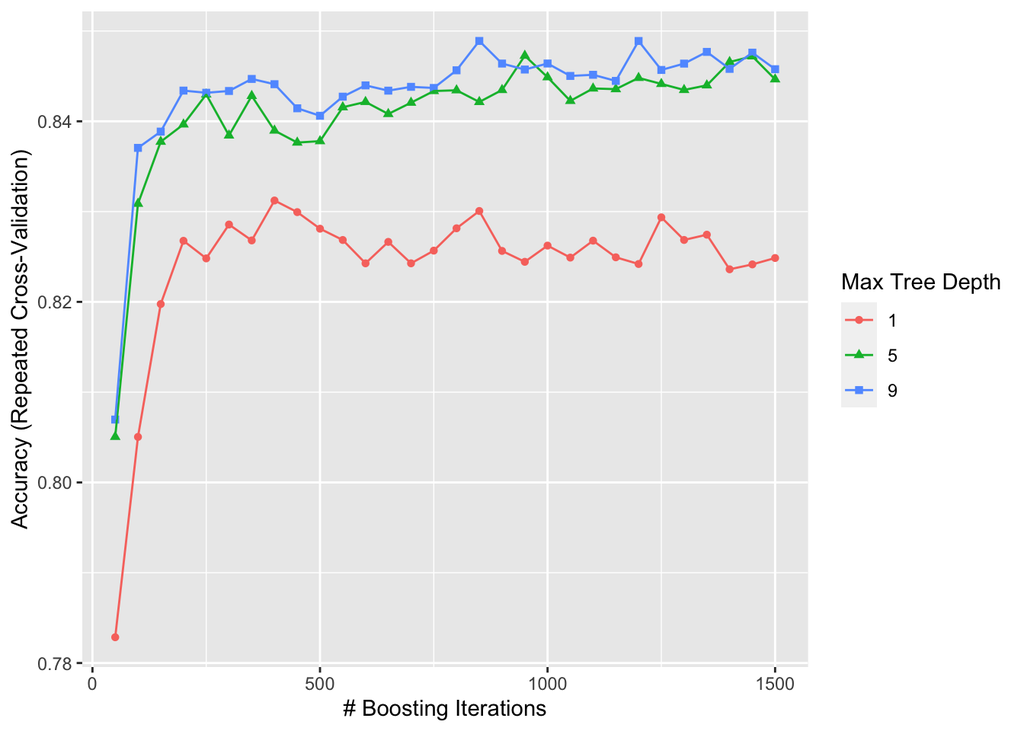

```r
ggplot(gbmFit2)
```

There are also plot functions that show more detailed representations of the resample the estimates. See `?xyplot.train` for more details.

From these plants, a different set of tuning parameters may be desired. To change the final values without starting the whole process again, the `update that train` can be used to refer to the final model see `?update.train`

#### 5.5.4 The `trainControl` Function

The function `trainControl` generates parameters that further control how models are created, with possible values :

- `method`: The sampling method : `"boot"` , `"cv"`, `"LOOCV"`, `"LGOCV`, `"repeatedcv`, `"timeslice"`, `"none"`, and `"oob"`.The last value, out of bag estimates, can only be used by random forest, bagged trees, bagged earth, bagged flexible discriminant analysis, or conditional tree models. GBM models are not included. Also, for leave-one-out cross validation, no uncertainty estimates are given for the resampled performances measures.
- `number` and `repeats`: `number` controls with the number of folds in *K*-fold cross validation or number of resampling iterations for bootstrapping and leave group-out-cross validation. `repeats` applied only to repeated K fold cross validation. Suppose that `method = "repeatedcv`, `number = 10` and `repeats = 3`, then three separate 10-fold corss-validations are used as the resampling scheme.
- `verboseIter`: A logical for printing a training log.
- `returnData`: A logical for saving the data into a slot called `trainingData`.
- `p`: For leave-group-out cross-validation: The training percentage
- for `method = "timeslice"`, `trainControl` has options `initialWindow`, `horizon`. and `fixedWindow` that govern how cross-validation can be used for time series data.
- `classProbs`: A logical value determining whether class probabilities should be computed for held-out samples during resample.
- `index` and `indexOut`: Optional lists with elements for each reasmpling iteration. Each list element is the sample rows used for training at that iteratin or should be held-out. When these valures are not specified, `train` will generate them.
- `summaryFunction`: A function to compute alternate performance summaries.
- `selectionFunction`: A function to choose the optimal tuning parameters, and examples.
- `PCAthresh`, `ICAcomp`, and `k`: These are all options to pass to the `preProcess` function (when used)
- `returnResamp`: A character string containing one of the following values: `"all"`, `"final"`, or `"none"`. This specifies how much of the resampled performance measures to save.
- `allowParallel`: A logical that governs whether `train` should use parallel processing (if available).

There are several other options not discussed here.

#### 5.5.5 Alternate Performance Metrics

The user can change the metric used to determine the best settings. By default, RMSE, $R^2$, and the mean absolute error (MAE) are computed for regression while accuracy and Kappa are computed for classification. Also by default, the parameter values are chosen using RMSE and accuracy, respectively for regression and classification. The `metric` argument of the `train` function allows the user to control which of the optimality criterion is used. For example, in problems where there is a low percentage of samples in one class, using `metric = "Kappa"` can improve the quality of the final model.

As shown in the last section, custom functions can be used to calculate performance scores that are averaged over the resamples. Another builg-in function, `twoClassSummary`, will compute the sensitivity, specificity and area under the ROC curve:

```r
head(twoClassSummary)
```

```
##
## 1 function (data, lev = NULL, model = NULL)
## 2 {
## 3     if (length(lev) > 2) {
## 4         stop(paste("Your outcome has", length(lev), "levels. The twoClassSummary() function isn't appropriate."))
## 5     }
## 6     requireNamespaceQuietStop("pROC")
```

To rebuild the boosted tree model using this criterion, we can see the relationship between the tuning parameters and the area under the ROC curve using the following code:

```r
fitControl <- trainControl(method = "repeatedcv",
                           number = 10,
                           repeats = 10,
                           ## Estimates class probabilities
                           classProbs = TRUE,
                           ## Evaluate performance using the following function
                           summaryFunction = twoClassSummary)

set.seed(825)
gbmfit3 <- train(Class ~ ., data = training,
                 method = "gbm",
                 trControl = fitControl,
                 verbose = FALSE,
                 tuneGrid = gbmGrid,
                 # Specify which metric to optimize
                 metric = "ROC")

gbmfit3$bestTune # The optimal model
```

```
##    n.trees interaction.depth shrinkage n.minobsinnode
## 37     350                 5       0.1             20
```

```r
which(gbmfit3$results$ROC >= 0.9213)
```

```
## [1] 20
```

```r
gbmfit3$results[20,]
```

```
##    shrinkage interaction.depth n.minobsinnode n.trees       ROC    Sens
## 37       0.1                 5             20     350 0.9213616 0.87125
##         Spec      ROCSD   SensSD    SpecSD
## 37 0.8094643 0.07420965 0.121239 0.1634282
```

### 5.6 Choosing the Final Model

`train` allows the user to specify alternate rules for selecting the final model. The argument `select function` can be used to supply a function to algorithmically determine the final model. There are three existing functions in the package: `best` chooses the largest/smallest value, `oneSE` attempts to capture the spirit of Breiman et at (1984) tand `tolerance` selects the least complex model within some percent tolerance of the best value. See `?best` for more details.

User-defined functions can be used, as long as they have the following arguments:

- `x` is a data frame containing the tune parameters and their associated performance metrics. Each row corresponds to a different tuning parameter combination.
- `metric` is a character string indicating which performance metric should be optimized (this is passed in directly from the `metric` argument of `train`).
- `maximize` is a single logical value indicating whether larger values of the performance metric are better (this is also directly passed from the call to `train`).

The function should output a single integer indicating which row in `x` is chosen.

The tolerance function can be used to find a less complex model based on $\frac{x - x_{best}}{x_{best} x 100}$, which is the percent difference. For example, to select parameter values based on a 2% loss of performance:

```r
whichTwoPct <- tolerance(gbmfit3$results, metric = "ROC",
                         tol = 2, maximize = TRUE)
cat("best model within 2 pct of best:\n")
```

```
## best model within 2 pct of best:
```

```r
gbmfit3$results[whichTwoPct, 1:6]
```

```
##    shrinkage interaction.depth n.minobsinnode n.trees       ROC      Sens
## 32       0.1                 5             20     100 0.9139707 0.8645833
```

The main issue with these functions is related to ordering the models from simplest to complex. In some cases this is easy(e.g. Simple trees, partial least squares. But in case of such this model, the ordering of models is subjective. For example, is a boosted three model using 100 iterations and a three depth of two more complex than one with 50 iterations in a three depth of eight? The package makes some choices regarding these order. In the case of boosted trees, the package assumes that increasing the number of iterations adds complexity at a faster rate than increasing the tree depth, some models are ordered on the number of iterations then ordered on depth. See `?best` for more examples for specific models.